# STAT 240 Discussion 10

316:4 `**Nico Salm**, Dheeraj Pasikanti, Jinming Liu, Michelle Kim`

For today’s discussion, you should spend about **half the time working on this file**, and then spend the **other half working in your groups on the outline**. Make sure to check in with your TA if you have any questions about your proposal feedback!

## Data

The data set `boston-marathon-2010-sample.csv` contains a random sample of 50 men and 50 women, aged 35–39, who ran in and completed the 2010 Boston Marathon. Times are in minutes.

```r
bm <- read_csv("../../data/boston-marathon-2010-sample.csv")
```

## Problems

The questions in this discussion assignment use a subset of the 2010 Boston Marathon data set described above.

### Problem 1

Display the data using side-by-side boxplots with the sex of the competitor on the x axis and their time on the y axis. Add an appropriate title and axis labels to the plot.

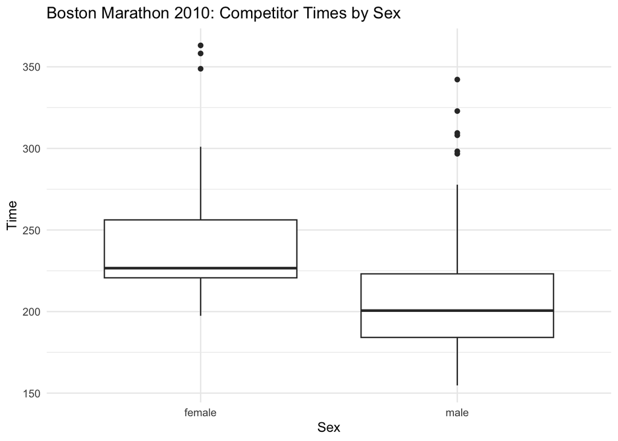

```r
ggplot(bm, aes(x = Sex, y = Time)) +
  geom_boxplot() +
  labs(title = "Boston Marathon 2010: Competitor Times by Sex",
       x = "Sex",
       y = "Time") +
  theme_minimal()
```

### Problem 2

Create and display a table with a numerical summary of the data. Calculate the sample size, mean time, standard deviation of the times, and standard error of the mean ($s/\sqrt{n}$) separately for each sex. This table will have one row for each sex.

```r
table_data <- bm %>%
  group_by(Sex) %>%
  summarise(n = n(),
            mean = mean(Time),
            sd = sd(Time),
            se = sd(Time)/sqrt(n))
table_data
```

```
## # A tibble: 2 × 5
##   Sex        n  mean    sd    se
##   <chr>  <int> <dbl> <dbl> <dbl>
## 1 female    50  242.  39.3  5.56
## 2 male      50  213.  44.8  6.33
```

### Problem 3

Using the function `t.test()`, construct separate 95% confidence intervals for each sex for the mean time to complete the 2010 Boston Marathon among all competitors of that sex aged 35–39.

```r
ci_male <- t.test(bm$Time[bm$Sex == "male"], conf.level = 0.95)
ci_female <- t.test(bm$Time[bm$Sex == "female"], conf.level = 0.95)

ci_male
```

```
##
##  One Sample t-test
##
## data:  bm$Time[bm$Sex == "male"]
## t = 33.691, df = 49, p-value < 2.2e-16
## alternative hypothesis: true mean is not equal to 0
## 95 percent confidence interval:
##  200.6301 226.0819
## sample estimates:
## mean of x
##   213.356
```

```r
ci_female
```

```
##
##  One Sample t-test
##
## data:  bm$Time[bm$Sex == "female"]
## t = 43.498, df = 49, p-value < 2.2e-16
## alternative hypothesis: true mean is not equal to 0
## 95 percent confidence interval:
##  230.7624 253.1176
## sample estimates:
## mean of x
##    241.94
```

### Problem 4

Without using the function `t.test()` write code to calculate the end points of the 95% confidence interval for the mean time for women aged 35–39 to complete the 2010 Boston Marathon.

```r
bm_filtered <- bm %>% filter(Sex == "female")

mean_time <- mean(bm_filtered$Time)
sd_time <- sd(bm_filtered$Time)
n <- nrow(bm_filtered)
std_error <- sd_time/sqrt(n)

alpha = 0.05

t_crit <- qt(1 - alpha/2, df = n - 1)

lower <- mean_time - t_crit * std_error
upper <- mean_time + t_crit * std_error

c(lower, upper)
```

```
## [1] 230.7624 253.1176
```

### Problem 5

Write an interpretation of the confidence interval from the previous problem in context, following course examples.

Based on our sample, we are 95% confident that the true mean completion time for the 2010 Boston Marathon among women aged 35-39 lies between 230.76 and 253.12 minutes. This interval estimates the population average and implies a 5% chance that it does not include the true mean.